# NYC Tree Canopy and Forestry Service Requests Analysis

By Jessica Saab  
For NYU Spatial Analysis and Visualization, Fall 2021

### Loading libraries

```r
library(tidyverse)
## ── Attaching packages ─────────────────────────────────────── tidyverse 1.3.1 ──
## ✓ ggplot2 3.3.5     ✓ purrr   0.3.4
## ✓ tibble  3.1.5     ✓ dplyr   1.0.7
## ✓ tidyr   1.1.4     ✓ stringr 1.4.0
## ✓ readr   2.0.2     ✓ forcats 0.5.1
## ── Conflicts ────────────────────────────────────────── tidyverse_conflicts() ──
## x dplyr::filter() masks stats::filter()
## x dplyr::lag()    masks stats::lag()
library(fs)
library(readr)
library(dplyr)
library(ggplot2)
library(janitor)
##
## Attaching package: 'janitor'
## The following objects are masked from 'package:stats':
##
##     chisq.test, fisher.test
library(skimr)
library(ggthemes)

# bringing in a raw file and creating a clean version
calls_raw <- read_csv("Forestry_Service_Requests.csv",
                      col_types = cols(CommunityBoard = col_character(),
                                       Postcode = col_character(),
                                       InitiatedDate = col_datetime(format = "%m/%d/%Y %H:%M:%S"),
                                       ClosedDate = col_datetime(format = "%m/%d/%Y %H:%M:%S"),
                                       )
                      ) %>%  clean_names

canopy <- read_csv("ny4p_tree_canopy_coverage.csv") %>% clean_names %>% rename("cb_name" = cb)
## Rows: 59 Columns: 3
## ── Column specification ────────────────────────────────────────────────────────
## Delimiter: ","
## chr (1): cb
## dbl (2): canopy_cover, rank
##
## ℹ Use `spec()` to retrieve the full column specification for this data.
## ℹ Specify the column types or set `show_col_types = FALSE` to quiet this message.
```

### Creating a main dataset

My first dataset catalogs Forestry Service Requests to the NYC Parks Department.  
Source: https://data.cityofnewyork.us/Environment/Forestry-Service-Requests/mu46-p9is

I first took a look at the data to select some columns for analysis.  
With over 650,000 obervations and 47 columns, there was a lot of data to look at.  
I selected seven columns, renamed them, filtered out irregular values, and created some new columns with values.  
Then I selected a subset and arranged them by date.

My second dataset catalogs tree canopy cover in NYC.  
Source: http://www.ny4p.org/data-and-research/research-library/open-space-profiles  
It was aggregated by New Yorkers for Parks, a nonprofit organization that advocates for and researches open space in NYC. The dateset is not available to the public but I selected a specific measurement from their 2021 Open Space Profiles, which are available as PDFs, and created a simple CSV with the information on tree canopy cover.

```r
calls <- select(calls_raw, # selecting columns from the full dataset
  sr_status, # whether the case is open or closed
  sr_category, # type of forestry request or concern
  sr_priority, # priority level given by agency
  borough_code, # borough name
  community_board, # community board
  initiated_date, # start date
  closed_date # end date
  ) %>%
  rename( # renaming columns
    "status" = sr_status,
    "category" = sr_category,
    "priority" = sr_priority,
    "cb" = community_board,
    "start_date" = initiated_date,
    "end_date" = closed_date
    ) %>%
  filter(str_length(cb) == 3) %>% # filtering out community board codes that are not three digits
  filter(!is.na(cb)) %>% # filtering out community boards that are NULL
  filter(!is.na(start_date)) %>% # filtering out start dates that are NULL
  filter(!is.na(end_date)) %>% # filtering out end dates that are NULL which are open cases
  filter(category != "Remove Debris") %>% #only two years of data
  filter(category != "Remove Stump") %>% #only two years of data
  mutate( # making new columns
    boro = str_sub(cb, 1, 1), # taking the first digit to find the boro
    district = str_sub(cb, 2, 3), # taking the last two digits to find the community board
    start = (str_sub(start_date, 1, 7)),
    end = (str_sub(end_date, 1, 7)),
    boro_initials = recode(
      boro, "1" = "MN", "2" = "BX", "3" = "BK", "4" = "QN", "5" = "SI"),
    boro_name = recode(
      boro, "1" = "Manhattan", "2" = "Bronx", "3" = "Brooklyn", "4" = "Queens", "5" = "Staten Island"),
    cb_name = str_c(boro_initials, district)
  ) %>%
  select(boro_name, cb_name, start, end, status, priority, category) %>%
  arrange(start)
calls <- left_join(calls, canopy, "cb_name" = "cb_name") # joining my two datasets together
calls
```

```
## # A tibble: 538,691 × 9
##    boro_name  cb_name start  end   status priority category   canopy_cover  rank
##    <chr>      <chr>   <chr>  <chr> <chr>  <chr>    <chr>             <dbl> <dbl>
##  1 Brooklyn   BK13    2015-… 2016… Closed Routine  Plant Tree         0.12    52
##  2 Brooklyn   BK11    2015-… 2016… Closed Routine  Plant Tree         0.12    52
##  3 Queens     QN03    2015-… 2015… Closed Routine  Plant Tree         0.18    30
##  4 Staten Is… SI01    2015-… 2016… Closed Routine  Plant Tree         0.28     6
##  5 Queens     QN13    2015-… 2020… Closed Routine  Prune              0.21    14
##  6 Bronx      BX09    2015-… 2015… Closed Routine  Root/Sewe…         0.2     19
##  7 Queens     QN12    2015-… 2015… Closed Routine  Root/Sewe…         0.19    22
##  8 Brooklyn   BK09    2015-… 2016… Closed Routine  Prune              0.17    34
##  9 Bronx      BX10    2015-… 2015… Closed Routine  Root/Sewe…         0.17    34
## 10 Brooklyn   BK17    2015-… 2017… Closed Routine  Plant Tree         0.16    43
## # … with 538,681 more rows
```

### Analysis: Tree canopy coverage in NYC

Finding the average of tree canopy coverage by borough

```r
canopy_nyc <- calls %>%
  group_by(boro_name) %>%
  summarise(canopy_cover = mean(canopy_cover, na.rm = TRUE))
canopy_nyc
```

```
## # A tibble: 5 × 2
##   boro_name     canopy_cover
##   <chr>                <dbl>
## 1 Bronx                0.210
## 2 Brooklyn             0.179
## 3 Manhattan            0.197
## 4 Queens               0.209
## 5 Staten Island        0.245
```

### Plot: Ranking of tree canopy coverage in NYC boroughs

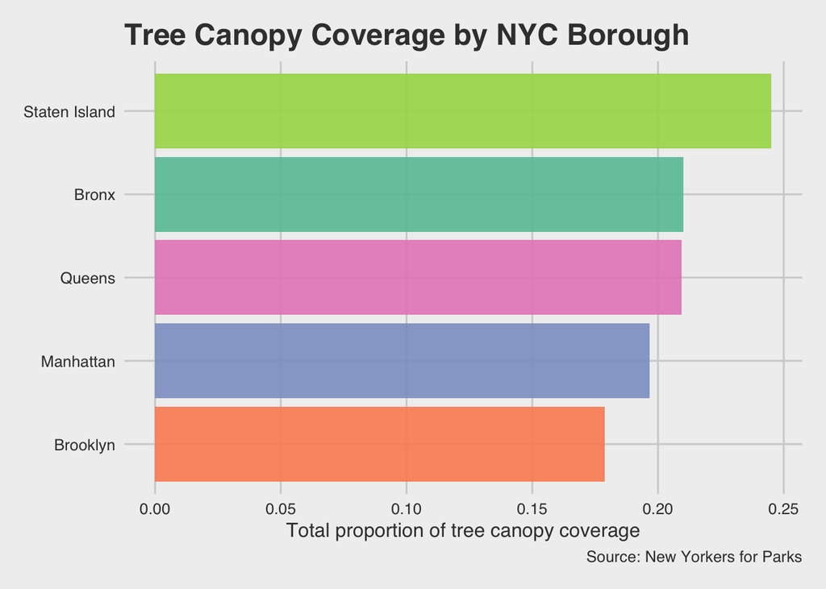

```r
canopy_nyc_plot <- ggplot(canopy_nyc, aes(reorder(boro_name, canopy_cover), canopy_cover, fill = boro_name)) +
  geom_col(size = 1, alpha = 0.9) +
  coord_flip() +
  scale_y_continuous() +
  theme_fivethirtyeight() +
  theme(axis.title = element_text(), axis.title.y = element_blank()) +
  theme(legend.position = "NONE") +
  labs(
    title = "Tree Canopy Coverage by NYC Borough",
    y = "Total proportion of tree canopy coverage",
    caption = "Source: New Yorkers for Parks"
  ) +
  scale_fill_brewer(palette = "Set2")
canopy_nyc_plot
```

### Analysis: Finding out total service calls by borough

Finding total number of calls by borough, excluding open cases, by grouping by year and borough, and sorting by number of calls.

```r
calls_boro <- calls %>%
  mutate(year = str_sub(start, 1, 4)) %>%
  group_by(year, boro_name) %>%
  summarise(total_calls = n()) %>%
  arrange(desc(total_calls)) %>%
  ungroup()
calls_boro
```

```
## # A tibble: 35 × 3
##    year  boro_name total_calls
##    <chr> <chr>           <int>
##  1 2020  Queens          48308
##  2 2018  Queens          36122
##  3 2020  Brooklyn        34661
##  4 2017  Queens          31176
##  5 2018  Brooklyn        29162
##  6 2016  Queens          28370
##  7 2019  Queens          27533
##  8 2015  Queens          25716
##  9 2017  Brooklyn        25656
## 10 2016  Brooklyn        25366
## # … with 25 more rows
```

### Analysis: Finding out total types of service calls by borough

Finding total number of types of calls by borough, excluding open cases, by grouping by year and borough and category, and sorting by number of calls.

```r
call_types_boro <- calls %>%
  mutate(year = str_sub(start, 1, 4)) %>%
  group_by(year, boro_name, category) %>%
  summarise(total_calls = n()) %>%
  arrange(desc(total_calls)) %>%
  ungroup()
call_types_boro
```

```
## # A tibble: 210 × 4
##    year  boro_name category   total_calls
##    <chr> <chr>     <chr>            <int>
##  1 2020  Queens    Hazard           31108
##  2 2020  Brooklyn  Hazard           23633
##  3 2018  Queens    Hazard           13968
##  4 2018  Brooklyn  Hazard           10600
##  5 2019  Queens    Hazard            9380
##  6 2017  Queens    Hazard            9204
##  7 2016  Queens    Hazard            8856
##  8 2019  Brooklyn  Hazard            8056
##  9 2016  Brooklyn  Plant Tree        7751
## 10 2020  Queens    Prune             7354
## # … with 200 more rows
```

### Plot: Calls by Borough in all NYC

Creating a bar graph of total calls by borough.

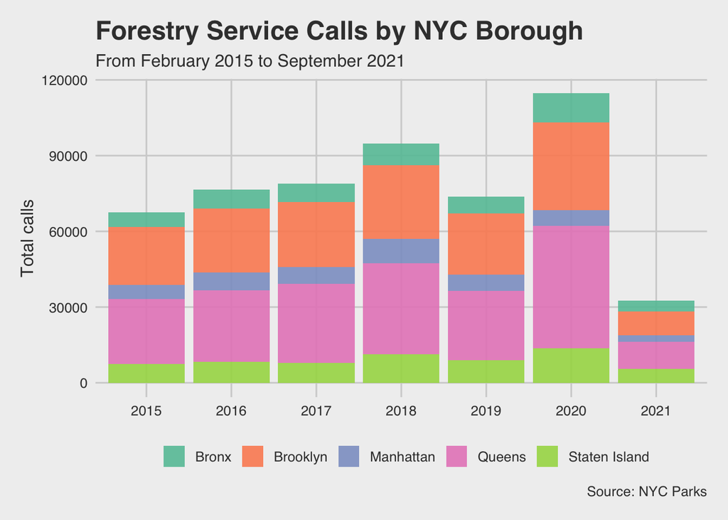

```r
calls_boro_plot <- ggplot(calls_boro, aes(year, total_calls, group = boro_name, fill = boro_name)) +
  geom_col(size= 1, alpha = 0.9) +
  scale_y_continuous() +
  theme_fivethirtyeight() +
  theme(axis.title = element_text(), legend.title = element_blank(), axis.title.x = element_blank()) +
  labs(
    title = "Forestry Service Calls by NYC Borough",
    subtitle = "From February 2015 to September 2021",
    y = "Total calls",
    color = "Boroughs",
    caption = "Source: NYC Parks"
    ) +
  scale_fill_brewer(palette = "Set2")
calls_boro_plot
```

### Plot: Types of Calls in all NYC

Creating a bar graph of total types of calls by borough.

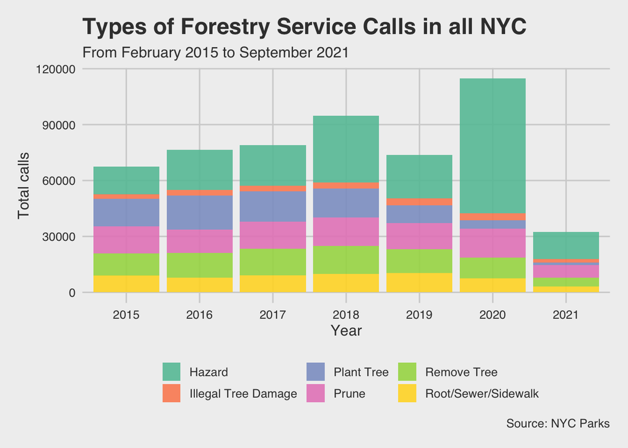

```r
call_types_nyc_plot <- ggplot(call_types_boro, aes(year, total_calls, group = category, fill = category)) +
  geom_col(size= 1, alpha = 0.9) +
  theme_fivethirtyeight() +
  theme(axis.title = element_text(), legend.title = element_blank()) +
  labs(
    title = "Types of Forestry Service Calls in all NYC",
    subtitle = "From February 2015 to September 2021",
    x = "Year",
    y = "Total calls",
    color = "Boroughs",
    caption = "Source: NYC Parks"
    ) +
  scale_fill_brewer(palette = "Set2")
call_types_nyc_plot
```

### Plot: Types of Calls by Borough

Creating a bar graph of total types of calls for each borough.

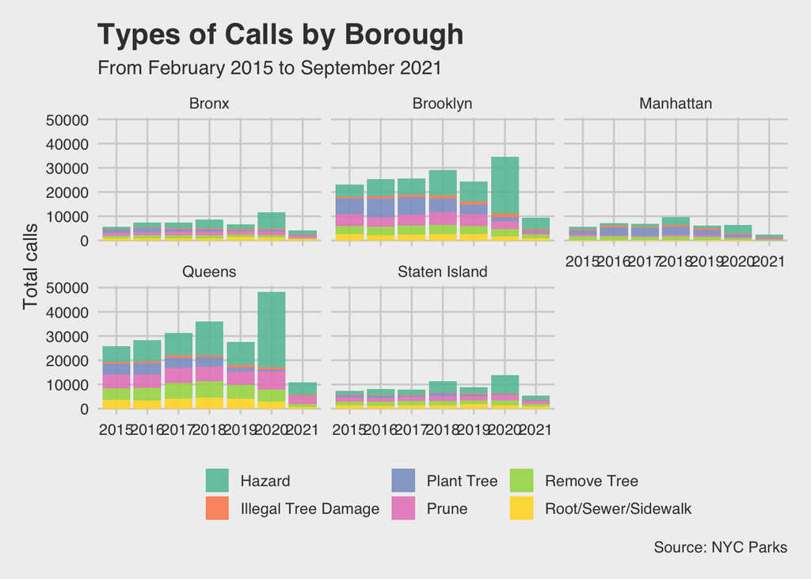

```r
call_types_boro_plot <- ggplot(call_types_boro, aes(year, total_calls, group = category, fill = category)) +
  geom_col(size = 1, alpha = 0.9) +
  scale_y_continuous() +
  theme_fivethirtyeight() +
  theme(axis.title = element_text(), legend.title = element_blank(), axis.title.x = element_blank()) +
  labs(
    title = "Types of Calls by Borough",
    subtitle = "From February 2015 to September 2021",
    x = "Year",
    y = "Total calls",
    color = "Boroughs",
    caption = "Source: NYC Parks"
  ) +
  scale_fill_brewer(palette = "Set2") +
  facet_wrap(~boro_name)
call_types_boro_plot
```

### Analysis: Calls by Community Board

Finding total number of calls and average of canopy cover by community board, excluding open cases, by filtering out non-community board values and grouping by district and borough.

```r
calls_cb <- calls %>%
  filter(cb_name != "MN64") %>%
  filter(cb_name != "BX26") %>%
  filter(cb_name != "BX27") %>%
  filter(cb_name != "BX28") %>%
  filter(cb_name != "BK55") %>%
  filter(cb_name != "BK56") %>%
  filter(cb_name != "QN80") %>%
  filter(cb_name != "QN81") %>%
  filter(cb_name != "QN82") %>%
  filter(cb_name != "QN83") %>%
  filter(cb_name != "QN84") %>%
  filter(cb_name != "SI95") %>%
  group_by(cb_name, boro_name) %>%
  summarise(
    total_calls = n(),
    canopy_cover = mean(canopy_cover, na.rm = TRUE),
    ) %>%
  arrange(desc(total_calls)) %>%
  ungroup()
calls_cb
```

```
## # A tibble: 59 × 4
##    cb_name boro_name     total_calls canopy_cover
##    <chr>   <chr>               <int>        <dbl>
##  1 QN13    Queens              28542         0.21
##  2 SI03    Staten Island       27297         0.18
##  3 QN07    Queens              23360         0.2
##  4 QN11    Queens              22707         0.32
##  5 BK18    Brooklyn            21453         0.19
##  6 QN05    Queens              20710         0.19
##  7 QN12    Queens              20000         0.19
##  8 BK15    Brooklyn            18441         0.17
##  9 SI01    Staten Island       17888         0.28
## 10 SI02    Staten Island       17825         0.31
## # … with 49 more rows
```

### Analysis: Types of calls by Community Board

Finding total number of types of calls by community board, excluding open cases, by grouping by year, community board, borough, and category, and sorting by number of calls.

```r
call_types_cb <- calls %>%
  mutate(year = str_sub(start, 1, 4)) %>%
  group_by(year, cb_name, boro_name, category) %>%
  summarise(total_calls = n()) %>%
  arrange(desc(total_calls)) %>%
  ungroup()
call_types_cb
```

```
## # A tibble: 2,630 × 5
##    year  cb_name boro_name     category total_calls
##    <chr> <chr>   <chr>         <chr>          <int>
##  1 2020  QN13    Queens        Hazard          4372
##  2 2020  QN07    Queens        Hazard          3833
##  3 2020  BK18    Brooklyn      Hazard          3788
##  4 2020  SI03    Staten Island Hazard          3385
##  5 2020  QN11    Queens        Hazard          3252
##  6 2020  QN12    Queens        Hazard          3089
##  7 2020  QN08    Queens        Hazard          2811
##  8 2020  BK15    Brooklyn      Hazard          2804
##  9 2020  QN10    Queens        Hazard          2625
## 10 2020  QN09    Queens        Hazard          2408
## # … with 2,620 more rows
```

### Plot: Ranking of Service Calls by Community Boards

Creating a bar graph of total calls by community boards.

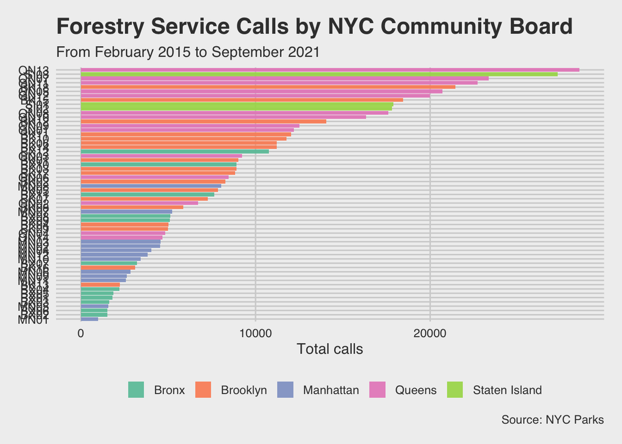

```r
calls_cb_plot <-
  ggplot(calls_cb, aes(reorder(cb_name, total_calls), total_calls, fill = boro_name)) +
  geom_col(size= 3, alpha = 0.9) +
  coord_flip() +
  scale_y_continuous() +
  theme_fivethirtyeight() +
  theme(
    axis.title = element_text(),
    legend.title = element_blank(),
    axis.title.y = element_blank()
    ) +
  labs(
    title = "Forestry Service Calls by NYC Community Board",
    subtitle = "From February 2015 to September 2021",
    x = "Community Boards",
    y = "Total calls",
    caption = "Source: NYC Parks"
  ) +
  scale_fill_brewer(palette = "Set2")
calls_cb_plot
```

### Plot: Ranking of Tree Canopy Cover by Community Board

Creating a bar graph of total tree canopy coverage by community boards.

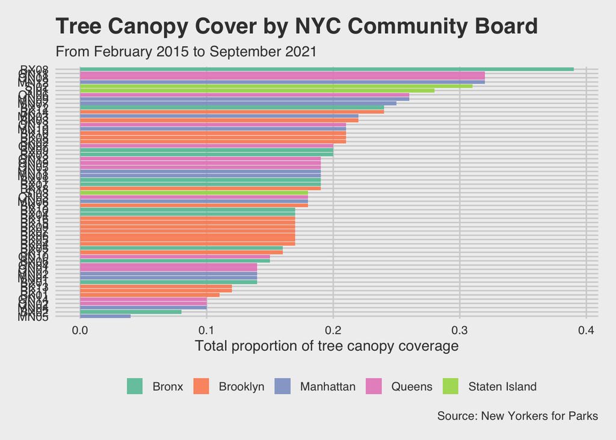

```r
canopy_cb_plot <-
  ggplot(calls_cb, aes(reorder(cb_name, canopy_cover), canopy_cover, fill = boro_name)) +
  geom_col(size= 3, alpha = 0.9) +
  coord_flip() +
  scale_y_continuous() +
  theme_fivethirtyeight() +
  theme(
    axis.title = element_text(),
    legend.title = element_blank(),
    axis.title.y = element_blank()
    ) +
  labs(
    title = "Tree Canopy Cover by NYC Community Board",
    subtitle = "From February 2015 to September 2021",
    x = "Community Boards",
    y = "Total proportion of tree canopy coverage",
    caption = "Source: New Yorkers for Parks"
  ) +
  scale_fill_brewer(palette = "Set2")
canopy_cb_plot
```

### Plot: Tree Canopy Coverage vs. Forestry Service Calls

Creating a scatterplot of tree canopy coverage and total calls by community board.

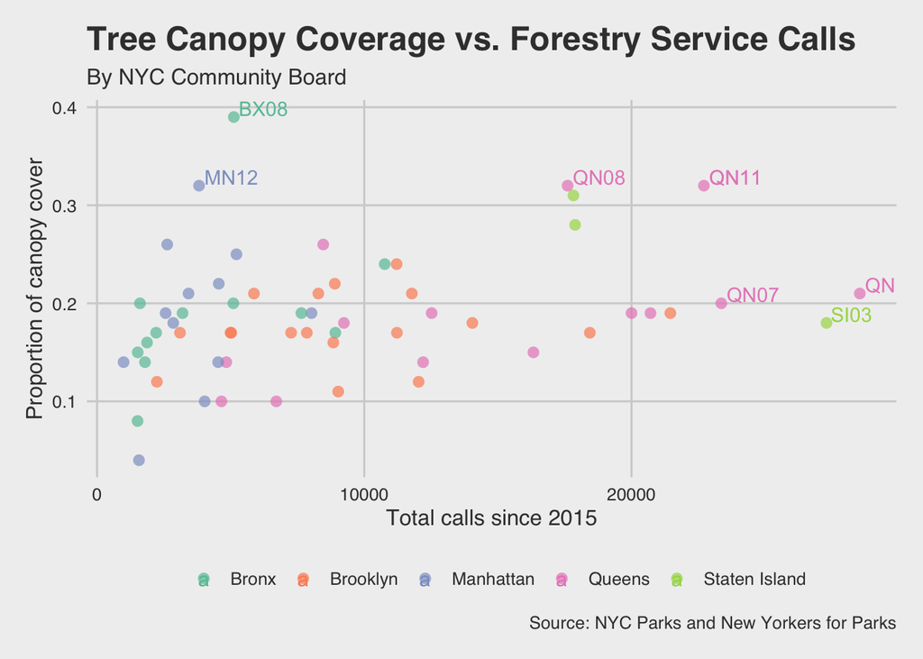

```r
calls_vs_canopy <-
  ggplot(calls_cb, aes(total_calls, canopy_cover, color = boro_name, label = cb_name)) +
  geom_point(size= 3, alpha = 0.7, stroke = 0) +
  geom_text(aes(label=ifelse(total_calls>22000,as.character(cb_name),'')),hjust=-0.1,vjust=-0.1) +
  geom_text(aes(label=ifelse(canopy_cover>0.31,as.character(cb_name),'')),hjust=-0.1,vjust=-0.1) +
  theme_fivethirtyeight() +
  theme(
    axis.title = element_text(),
    legend.title = element_blank()
    ) +
  labs(
    title = "Tree Canopy Coverage vs. Forestry Service Calls",
    subtitle = "By NYC Community Board",
    x = "Total calls since 2015",
    y = "Proportion of canopy cover",
    caption = "Source: NYC Parks and New Yorkers for Parks"
  ) +
  scale_color_brewer(palette = "Set2")
calls_vs_canopy
```